# TO404HW2

Maxwell Cornellier

11/8/2020

###Library Inputs

```r
library(dplyr)
```

```r
library("ggplot2")
```

# 1. Understand the Data

###Download Data Files & Take 5% Sample of Each

```r
Jan2019 <- read.csv("201901-citibike-tripdata.csv")
SampleJan2019 <- sample_frac(Jan2019,0.05)
SampleFeb2019 <- sample_frac((read.csv("201902-citibike-tripdata.csv")),0.05)
SampleMar2019 <- sample_frac((read.csv("201903-citibike-tripdata.csv")),0.05)
SampleApril2019 <- sample_frac((read.csv("201904-citibike-tripdata.csv")),0.05)
SampleMay2019 <- sample_frac((read.csv("201905-citibike-tripdata.csv")),0.05)
SampleJune2019 <- sample_frac((read.csv("201906-citibike-tripdata.csv")),0.05)
SampleJuly2019 <- sample_frac((read.csv("201907-citibike-tripdata.csv")),0.05)
SampleAugust2019 <- sample_frac((read.csv("201908-citibike-tripdata.csv")),0.05)
SampleSept2019 <- sample_frac((read.csv("201909-citibike-tripdata.csv")),0.05)
SampleOct2019 <- sample_frac((read.csv("201910-citibike-tripdata.csv")),0.05)
SampleNov2019 <- sample_frac((read.csv("201911-citibike-tripdata.csv")),0.05)
SampleDec2019 <- sample_frac((read.csv("201912-citibike-tripdata.csv")),0.05)
```

### Combine Data Files into one Table

```r
CitiBike2019 <- rbind(SampleJan2019,SampleFeb2019,SampleMar2019, SampleApril2019, SampleMay2019, SampleJune2019, SampleJuly2019, SampleAugust2019, SampleSept2019, SampleOct2019, SampleNov2019, SampleDec2019)

# Clean Data

## Change Variables to Factors as necessary

CitiBike2019$start.station.id <- as.factor(CitiBike2019$start.station.id)
CitiBike2019$end.station.id <- as.factor(CitiBike2019$end.station.id)
CitiBike2019$end.station.name <- as.factor(CitiBike2019$end.station.name)
CitiBike2019$start.station.name <- as.factor(CitiBike2019$start.station.name)
CitiBike2019$usertype <- as.factor(CitiBike2019$usertype)
CitiBike2019$gender <- as.factor(CitiBike2019$gender)
CitiBike2019$bikeid <- as.factor(CitiBike2019$bikeid)
CitiBike2019$starttime <- as.POSIXct(CitiBike2019$starttime)
CitiBike2019$stoptime <- as.POSIXct(CitiBike2019$stoptime)
```

## Descriptive Stats and Visualizations

```r
# Average Trip Duration

arr_tripduration <- mean(CitiBike2019$tripduration, na.rm = T)

# Longest trip duration

longest_trip<- max(CitiBike2019$tripduration, na.rm = T)


# Shortest trip duration

shortest_trip <- min(CitiBike2019$tripduration, na.rm = T)
```

The average trip duration for a Citi Bike ride in 2019 was 977.4982109 seconds

The shortest trip by duration on a Citi Bike in 2019 was 61 seconds

#Stats, Visualizations, and Patterns

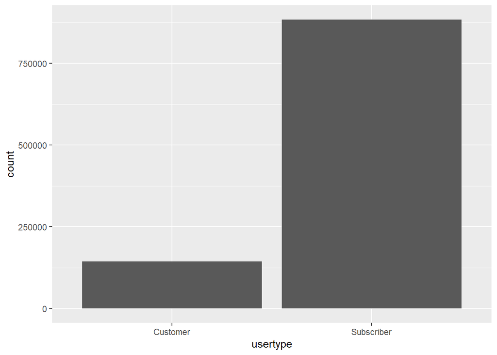

```r
# Number of Citi Bike Stations

number_endstations <- length(levels(CitiBike2019$end.station.id))

#Citi bike Rides in 2019 by User type

CountCustumer <- nrow(CitiBike2019[CitiBike2019$usertype == "Customer",])
CountSubscriber <- nrow(CitiBike2019[CitiBike2019$usertype == "Subscriber",])
TotalRides <- nrow(CitiBike2019)

baseplot <- ggplot(data=CitiBike2019, aes(x= usertype))
baseplot + geom_histogram(stat="count")
```

Number of Citi Bike End Station is 936

Number of Citi Bike rides by users who are “Customers” is 144200 Number of Citi Bike rides by users who are “Subscribers” is 883383

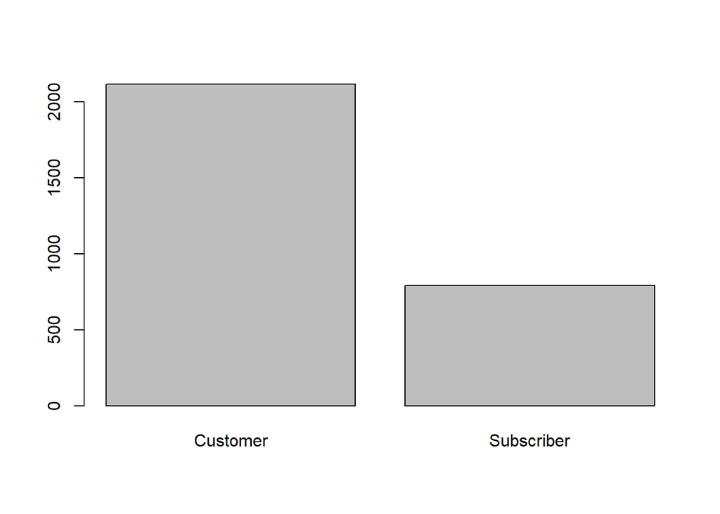

```r
#Average Trip Duration by User Type

avgtrip_usertype <- tapply(CitiBike2019$tripduration,CitiBike2019$usertype, mean, na.rm = T)


barplot(sort(avgtrip_usertype, decreasing = T))
```

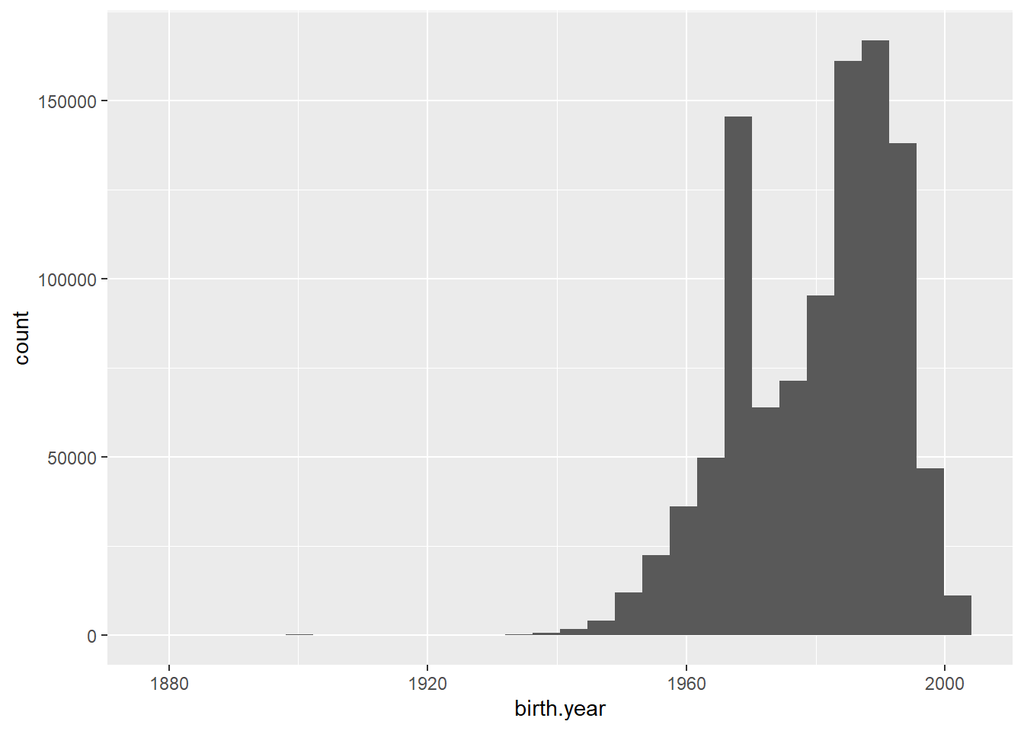

```r
# User Type by Age Group




baseplot2 <- ggplot(data=CitiBike2019, aes( x= birth.year ), na.rm = T)
baseplot2 + geom_histogram()
```

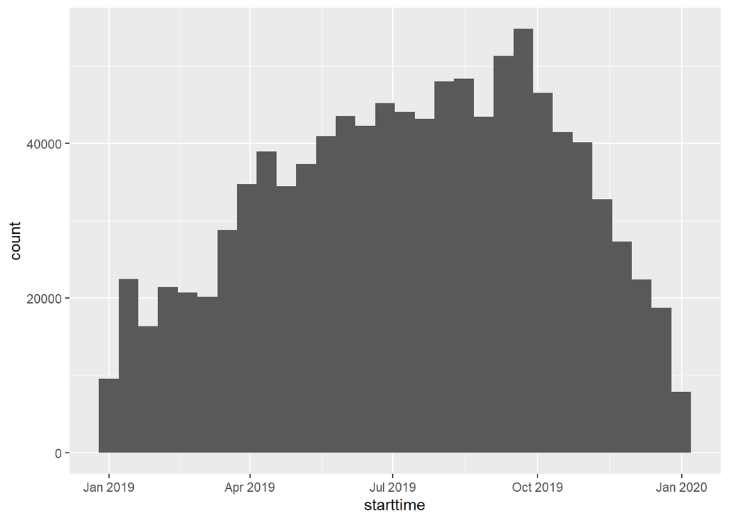

```r
# Average User Age

average_userage <- mean(CitiBike2019$birth.year)

# trip duration by month

baseplot3 <- ggplot(data = CitiBike2019, aes(x= starttime), na.rm = T)
baseplot3 + geom_histogram()
```

The average year of birth of a Citi Bike user in 2019 is 1980.2104463 making them about 39 years of age.

### Observations

Some takeaways are that Citi Bike riders are mainly subscribers that have short trip duration compared to a small percentage of Citi Bike Users who are “Customers” who have longer trip durations on average

It can also be seen that there are more start times during the summer months which makes sense given the weather in NYC and the limitations of bicycles in snowy conditions.

Citi Bike users are on average around 39 years old and face lower numbers among younger customers.